# IPND-Analyzing Soccer Data

## Objectives (Questions from the Data)

- How many teams played in each league during each season?  
- What was the count and average goals scored in each league during each season?

- How was the performance (home win, home tiem home loss, away win, away loss, away tie) of teams in each league during each season?  
- How to quantify the performance in terms of match results?

- Which players had the most penalties?  
- What player attributes lead to the most potential?  
- Correlation between some player attributes and player potential.

## Initial Setup

```python
#Imports
#Here we import the libraries that we will be using for data analysis in this project

import pandas as pd
import numpy as np
import matplotlib.pyplot as plt
import matplotlib.gridspec as gridspec
import seaborn as sns
import sqlite3
import pandasql as pdsql
from pandasql import sqldf
```

## Connection to the database

```python
#Start with creating a connection to the sqlite database and see what tables we have
conn = sqlite3.connect("database.sqlite")

list_of_tables = pd.read_sql("""SELECT *
                        FROM sqlite_master
                        WHERE type='table';""", conn)
list_of_tables
```

|  | type | name | tbl_name | rootpage | sql |
| --- | --- | --- | --- | --- | --- |
| 0 | table | sqlite_sequence | sqlite_sequence | 4 | CREATE TABLE sqlite_sequence(name,seq) |
| 1 | table | Player_Attributes | Player_Attributes | 11 | CREATE TABLE "Player_Attributes" (\n\t`id`\tIN... |
| 2 | table | Player | Player | 14 | CREATE TABLE `Player` (\n\t`id`\tINTEGER PRIMA... |
| 3 | table | Match | Match | 18 | CREATE TABLE `Match` (\n\t`id`\tINTEGER PRIMAR... |
| 4 | table | League | League | 24 | CREATE TABLE `League` (\n\t`id`\tINTEGER PRIMA... |
| 5 | table | Country | Country | 26 | CREATE TABLE `Country` (\n\t`id`\tINTEGER PRIM... |
| 6 | table | Team | Team | 29 | CREATE TABLE "Team" (\n\t`id`\tINTEGER PRIMARY... |
| 7 | table | Team_Attributes | Team_Attributes | 2 | CREATE TABLE `Team_Attributes` (\n\t`id`\tINTE... |

It appears there are 8 total tables in the database, 7 excluding the sequence table.

### Country Table

```python
Country_df = pd.read_sql_query("select * from Country;", conn)
Country_df
```

|  | id | name |
| --- | --- | --- |
| 0 | 1 | Belgium |
| 1 | 1729 | England |
| 2 | 4769 | France |
| 3 | 7809 | Germany |
| 4 | 10257 | Italy |
| 5 | 13274 | Netherlands |
| 6 | 15722 | Poland |
| 7 | 17642 | Portugal |
| 8 | 19694 | Scotland |
| 9 | 21518 | Spain |
| 10 | 24558 | Switzerland |

```python
#Writing a function to summarize/quickly analyze each table

def summarize_table(dataframename):

#         """" This function summarizes the content of a table/dataframe.
#              Args:
#                  dataframename (Pandas dataframe or sqlite table): .
#              Returns:
#                  Dimension of dataframe.
#                  Number and label and data type for each column.
#                  Total number of rows.
#                  Number of unique rows.
#                  First row.
#                  Summary statistics including count, mean, std, min, and max.
#                  Number of missing (null) values in each column.
#          """"

    print("Dimension of "+str("dataframename")+"table is: {}".format(dataframename.shape))
    print(100*"*")
    print(dataframename.info())
    print(100*"*")
    print(dataframename.select_dtypes(exclude=['float64','int64']).describe())
    print(100*"*")
    print(dataframename.describe())
    print(100*"*")
    print("Missing values of table is:")
    print(dataframename.isnull().sum(axis=0))
```

```python
summarize_table(Country_df)
```

```
Dimension of dataframenametable is: (11, 2)
<class 'pandas.core.frame.DataFrame'>
RangeIndex: 11 entries, 0 to 10
Data columns (total 2 columns):
id      11 non-null int64
name    11 non-null object
dtypes: int64(1), object(1)
memory usage: 256.0+ bytes
None
           name
count        11
unique       11
top     Germany
freq          1
                 id
count     11.000000
mean   12452.090909
std     8215.308472
min        1.000000
25%     6289.000000
50%    13274.000000
75%    18668.000000
max    24558.000000
Missing values of table is:
id      0
name    0
dtype: int64
```

Country table has no missing values.  
There are a total of 11 unique countries with their unique ids in this table.

### League Table

```python
League_df = pd.read_sql_query("select * from League;", conn)
League_df
```

|  | id | country_id | name |
| --- | --- | --- | --- |
| 0 | 1 | 1 | Belgium Jupiler League |
| 1 | 1729 | 1729 | England Premier League |
| 2 | 4769 | 4769 | France Ligue 1 |
| 3 | 7809 | 7809 | Germany 1. Bundesliga |
| 4 | 10257 | 10257 | Italy Serie A |
| 5 | 13274 | 13274 | Netherlands Eredivisie |
| 6 | 15722 | 15722 | Poland Ekstraklasa |
| 7 | 17642 | 17642 | Portugal Liga ZON Sagres |
| 8 | 19694 | 19694 | Scotland Premier League |
| 9 | 21518 | 21518 | Spain LIGA BBVA |
| 10 | 24558 | 24558 | Switzerland Super League |

```python
summarize_table(League_df)
```

```
Dimension of dataframenametable is: (11, 3)
<class 'pandas.core.frame.DataFrame'>
RangeIndex: 11 entries, 0 to 10
Data columns (total 3 columns):
id            11 non-null int64
country_id    11 non-null int64
name          11 non-null object
dtypes: int64(2), object(1)
memory usage: 344.0+ bytes
None
                            name
count                         11
unique                        11
top     Switzerland Super League
freq                           1
                 id    country_id
count     11.000000     11.000000
mean   12452.090909  12452.090909
std     8215.308472   8215.308472
min        1.000000      1.000000
25%     6289.000000   6289.000000
50%    13274.000000  13274.000000
75%    18668.000000  18668.000000
max    24558.000000  24558.000000
Missing values of table is:
id            0
country_id    0
name          0
dtype: int64
```

League table has no missing values.  
There are a total of 11 unique leagues with their unique ids in this table.

### Which League Belongs to Which Country

```python
#Since there are no missing values, I am going to use an inner join

Coubtry_League = pd.read_sql("""SELECT League.name AS League_Name, Country.name AS Country_Name
                        FROM League
                        JOIN Country ON Country.id = League.country_id;""", conn)
Coubtry_League
```

|  | League_Name | Country_Name |
| --- | --- | --- |
| 0 | Belgium Jupiler League | Belgium |
| 1 | England Premier League | England |
| 2 | France Ligue 1 | France |
| 3 | Germany 1. Bundesliga | Germany |
| 4 | Italy Serie A | Italy |
| 5 | Netherlands Eredivisie | Netherlands |
| 6 | Poland Ekstraklasa | Poland |
| 7 | Portugal Liga ZON Sagres | Portugal |
| 8 | Scotland Premier League | Scotland |
| 9 | Spain LIGA BBVA | Spain |
| 10 | Switzerland Super League | Switzerland |

It appears that League Names all contain the country name.  
There is not really a need to keep both fields.

### Match Table

```python
Match_df = pd.read_sql_query("select * from Match;", conn)
Match_df.head()
```

|  | id | country_id | league_id | season | stage | date | match_api_id | home_team_api_id | away_team_api_id | home_team_goal | ... | SJA | VCH | VCD | VCA | GBH | GBD | GBA | BSH | BSD | BSA |
| --- | --- | --- | --- | --- | --- | --- | --- | --- | --- | --- | --- | --- | --- | --- | --- | --- | --- | --- | --- | --- | --- |
| 0 | 1 | 1 | 1 | 2008/2009 | 1 | 2008-08-17 00:00:00 | 492473 | 9987 | 9993 | 1 | ... | 4.00 | 1.65 | 3.40 | 4.50 | 1.78 | 3.25 | 4.00 | 1.73 | 3.40 | 4.20 |
| 1 | 2 | 1 | 1 | 2008/2009 | 1 | 2008-08-16 00:00:00 | 492474 | 10000 | 9994 | 0 | ... | 3.80 | 2.00 | 3.25 | 3.25 | 1.85 | 3.25 | 3.75 | 1.91 | 3.25 | 3.60 |
| 2 | 3 | 1 | 1 | 2008/2009 | 1 | 2008-08-16 00:00:00 | 492475 | 9984 | 8635 | 0 | ... | 2.50 | 2.35 | 3.25 | 2.65 | 2.50 | 3.20 | 2.50 | 2.30 | 3.20 | 2.75 |
| 3 | 4 | 1 | 1 | 2008/2009 | 1 | 2008-08-17 00:00:00 | 492476 | 9991 | 9998 | 5 | ... | 7.50 | 1.45 | 3.75 | 6.50 | 1.50 | 3.75 | 5.50 | 1.44 | 3.75 | 6.50 |
| 4 | 5 | 1 | 1 | 2008/2009 | 1 | 2008-08-16 00:00:00 | 492477 | 7947 | 9985 | 1 | ... | 1.73 | 4.50 | 3.40 | 1.65 | 4.50 | 3.50 | 1.65 | 4.75 | 3.30 | 1.67 |

5 rows × 115 columns

```python
list(Match_df)
```

```
['id',
 'country_id',
 'league_id',
 'season',
 'stage',
 'date',
 'match_api_id',
 'home_team_api_id',
 'away_team_api_id',
 'home_team_goal',
 'away_team_goal',
 'home_player_X1',
 'home_player_X2',
 'home_player_X3',
 'home_player_X4',
 'home_player_X5',
 'home_player_X6',
 'home_player_X7',
 'home_player_X8',
 'home_player_X9',
 'home_player_X10',
 'home_player_X11',
 'away_player_X1',
 'away_player_X2',
 'away_player_X3',
 'away_player_X4',
 'away_player_X5',
 'away_player_X6',
 'away_player_X7',
 'away_player_X8',
 'away_player_X9',
 'away_player_X10',
 'away_player_X11',
 'home_player_Y1',
 'home_player_Y2',
 'home_player_Y3',
 'home_player_Y4',
 'home_player_Y5',
 'home_player_Y6',
 'home_player_Y7',
```

[output cut: 60 more lines]

```
 'WHH',
 'WHD',
 'WHA',
 'SJH',
 'SJD',
 'SJA',
 'VCH',
 'VCD',
 'VCA',
 'GBH',
 'GBD',
 'GBA',
 'BSH',
 'BSD',
 'BSA']
```

```python
summarize_table(Match_df)
```

```
Dimension of dataframenametable is: (25979, 115)
<class 'pandas.core.frame.DataFrame'>
RangeIndex: 25979 entries, 0 to 25978
Columns: 115 entries, id to BSA
dtypes: float64(96), int64(9), object(10)
memory usage: 22.8+ MB
None
           season                 date      goal      shoton      shotoff  \
count       25979                25979     14217       14217        14217
unique          8                 1694     13225        8464         8464
top     2015/2016  2009-04-11 00:00:00  <goal />  <shoton />  <shotoff />
freq         3326                   60       993        5754         5754

            foulcommit      card      cross      corner      possession
count            14217     14217      14217       14217           14217
unique            8466     13777       8466        8465            8420
top     <foulcommit />  <card />  <cross />  <corner />  <possession />
freq              5752       441       5752        5753            5798
                 id    country_id     league_id         stage  match_api_id  \
count  25979.000000  25979.000000  25979.000000  25979.000000  2.597900e+04
mean   12990.000000  11738.630317  11738.630317     18.242773  1.195429e+06
std     7499.635658   7553.936759   7553.936759     10.407354  4.946279e+05
min        1.000000      1.000000      1.000000      1.000000  4.831290e+05
25%     6495.500000   4769.000000   4769.000000      9.000000  7.684365e+05
50%    12990.000000  10257.000000  10257.000000     18.000000  1.147511e+06
75%    19484.500000  17642.000000  17642.000000     27.000000  1.709852e+06
max    25979.000000  24558.000000  24558.000000     38.000000  2.216672e+06

       home_team_api_id  away_team_api_id  home_team_goal  away_team_goal  \
count      25979.000000      25979.000000    25979.000000    25979.000000
mean        9984.371993       9984.475115        1.544594        1.160938
std        14087.453758      14087.445135        1.297158        1.142110
min         1601.000000       1601.000000        0.000000        0.000000
25%         8475.000000       8475.000000        1.000000        0.000000
50%         8697.000000       8697.000000        1.000000        1.000000
75%         9925.000000       9925.000000        2.000000        2.000000
max       274581.000000     274581.000000       10.000000        9.000000

       home_player_X1      ...                SJA           VCH           VCD  \
count    24158.000000      ...       17097.000000  22568.000000  22568.000000
```

[output cut: 77 more lines]

```
WHD                  3408
WHA                  3408
SJH                  8882
SJD                  8882
SJA                  8882
VCH                  3411
VCD                  3411
VCA                  3411
GBH                 11817
GBD                 11817
GBA                 11817
BSH                 11818
BSD                 11818
BSA                 11818
Length: 115, dtype: int64
```

There are lots of missing values in columns after home_player_X1.

### Player Table

```python
Player_df = pd.read_sql_query("select * from Player;", conn)
Player_df.head()
```

|  | id | player_api_id | player_name | player_fifa_api_id | birthday | height | weight |
| --- | --- | --- | --- | --- | --- | --- | --- |
| 0 | 1 | 505942 | Aaron Appindangoye | 218353 | 1992-02-29 00:00:00 | 182.88 | 187 |
| 1 | 2 | 155782 | Aaron Cresswell | 189615 | 1989-12-15 00:00:00 | 170.18 | 146 |
| 2 | 3 | 162549 | Aaron Doran | 186170 | 1991-05-13 00:00:00 | 170.18 | 163 |
| 3 | 4 | 30572 | Aaron Galindo | 140161 | 1982-05-08 00:00:00 | 182.88 | 198 |
| 4 | 5 | 23780 | Aaron Hughes | 17725 | 1979-11-08 00:00:00 | 182.88 | 154 |

```python
summarize_table(Player_df)
```

```
Dimension of dataframenametable is: (11060, 7)
<class 'pandas.core.frame.DataFrame'>
RangeIndex: 11060 entries, 0 to 11059
Data columns (total 7 columns):
id                    11060 non-null int64
player_api_id         11060 non-null int64
player_name           11060 non-null object
player_fifa_api_id    11060 non-null int64
birthday              11060 non-null object
height                11060 non-null float64
weight                11060 non-null int64
dtypes: float64(1), int64(4), object(2)
memory usage: 604.9+ KB
None
       player_name             birthday
count        11060                11060
unique       10848                 5762
top         Danilo  1989-03-02 00:00:00
freq             7                   10
                 id  player_api_id  player_fifa_api_id        height  \
count  11060.000000   11060.000000        11060.000000  11060.000000
mean    5537.511392  156582.427215       165664.910488    181.867445
std     3197.692647  160713.700624        58649.928360      6.369201
min        1.000000    2625.000000            2.000000    157.480000
25%     2767.750000   35555.500000       151889.500000    177.800000
50%     5536.500000   96619.500000       184671.000000    182.880000
75%     8306.250000  212470.500000       203883.250000    185.420000
max    11075.000000  750584.000000       234141.000000    208.280000

             weight
count  11060.000000
mean     168.380289
std       14.990217
min      117.000000
25%      159.000000
50%      168.000000
75%      179.000000
max      243.000000
Missing values of table is:
id                    0
player_api_id         0
player_name           0
player_fifa_api_id    0
birthday              0
height                0
weight                0
dtype: int64
```

There are no missing values in Player Table.

### Player Attribute Table

```python
Player_Attributes_df = pd.read_sql_query("select * from Player_Attributes;", conn)
Player_Attributes_df.head()
```

|  | id | player_fifa_api_id | player_api_id | date | overall_rating | potential | preferred_foot | attacking_work_rate | defensive_work_rate | crossing | ... | vision | penalties | marking | standing_tackle | sliding_tackle | gk_diving | gk_handling | gk_kicking | gk_positioning | gk_reflexes |
| --- | --- | --- | --- | --- | --- | --- | --- | --- | --- | --- | --- | --- | --- | --- | --- | --- | --- | --- | --- | --- | --- |
| 0 | 1 | 218353 | 505942 | 2016-02-18 00:00:00 | 67.0 | 71.0 | right | medium | medium | 49.0 | ... | 54.0 | 48.0 | 65.0 | 69.0 | 69.0 | 6.0 | 11.0 | 10.0 | 8.0 | 8.0 |
| 1 | 2 | 218353 | 505942 | 2015-11-19 00:00:00 | 67.0 | 71.0 | right | medium | medium | 49.0 | ... | 54.0 | 48.0 | 65.0 | 69.0 | 69.0 | 6.0 | 11.0 | 10.0 | 8.0 | 8.0 |
| 2 | 3 | 218353 | 505942 | 2015-09-21 00:00:00 | 62.0 | 66.0 | right | medium | medium | 49.0 | ... | 54.0 | 48.0 | 65.0 | 66.0 | 69.0 | 6.0 | 11.0 | 10.0 | 8.0 | 8.0 |
| 3 | 4 | 218353 | 505942 | 2015-03-20 00:00:00 | 61.0 | 65.0 | right | medium | medium | 48.0 | ... | 53.0 | 47.0 | 62.0 | 63.0 | 66.0 | 5.0 | 10.0 | 9.0 | 7.0 | 7.0 |
| 4 | 5 | 218353 | 505942 | 2007-02-22 00:00:00 | 61.0 | 65.0 | right | medium | medium | 48.0 | ... | 53.0 | 47.0 | 62.0 | 63.0 | 66.0 | 5.0 | 10.0 | 9.0 | 7.0 | 7.0 |

5 rows × 42 columns

```python
list(Player_Attributes_df)
```

```
['id',
 'player_fifa_api_id',
 'player_api_id',
 'date',
 'overall_rating',
 'potential',
 'preferred_foot',
 'attacking_work_rate',
 'defensive_work_rate',
 'crossing',
 'finishing',
 'heading_accuracy',
 'short_passing',
 'volleys',
 'dribbling',
 'curve',
 'free_kick_accuracy',
 'long_passing',
 'ball_control',
 'acceleration',
 'sprint_speed',
 'agility',
 'reactions',
 'balance',
 'shot_power',
 'jumping',
 'stamina',
 'strength',
 'long_shots',
 'aggression',
 'interceptions',
 'positioning',
 'vision',
 'penalties',
 'marking',
 'standing_tackle',
 'sliding_tackle',
 'gk_diving',
 'gk_handling',
 'gk_kicking',
 'gk_positioning',
 'gk_reflexes']
```

```python
summarize_table(Player_Attributes_df)
```

```
Dimension of dataframenametable is: (183978, 42)
<class 'pandas.core.frame.DataFrame'>
RangeIndex: 183978 entries, 0 to 183977
Data columns (total 42 columns):
id                     183978 non-null int64
player_fifa_api_id     183978 non-null int64
player_api_id          183978 non-null int64
date                   183978 non-null object
overall_rating         183142 non-null float64
potential              183142 non-null float64
preferred_foot         183142 non-null object
attacking_work_rate    180748 non-null object
defensive_work_rate    183142 non-null object
crossing               183142 non-null float64
finishing              183142 non-null float64
heading_accuracy       183142 non-null float64
short_passing          183142 non-null float64
volleys                181265 non-null float64
dribbling              183142 non-null float64
curve                  181265 non-null float64
free_kick_accuracy     183142 non-null float64
long_passing           183142 non-null float64
ball_control           183142 non-null float64
acceleration           183142 non-null float64
sprint_speed           183142 non-null float64
agility                181265 non-null float64
reactions              183142 non-null float64
balance                181265 non-null float64
shot_power             183142 non-null float64
jumping                181265 non-null float64
stamina                183142 non-null float64
strength               183142 non-null float64
long_shots             183142 non-null float64
aggression             183142 non-null float64
interceptions          183142 non-null float64
positioning            183142 non-null float64
vision                 181265 non-null float64
penalties              183142 non-null float64
marking                183142 non-null float64
standing_tackle        183142 non-null float64
```

[output cut: 110 more lines]

```
long_shots              836
aggression              836
interceptions           836
positioning             836
vision                 2713
penalties               836
marking                 836
standing_tackle         836
sliding_tackle         2713
gk_diving               836
gk_handling             836
gk_kicking              836
gk_positioning          836
gk_reflexes             836
dtype: int64
```

Many missing values in Player Attribute table.

```python
Team_df = pd.read_sql_query("select * from Team;", conn)
Team_df.head()
```

|  | id | team_api_id | team_fifa_api_id | team_long_name | team_short_name |
| --- | --- | --- | --- | --- | --- |
| 0 | 1 | 9987 | 673.0 | KRC Genk | GEN |
| 1 | 2 | 9993 | 675.0 | Beerschot AC | BAC |
| 2 | 3 | 10000 | 15005.0 | SV Zulte-Waregem | ZUL |
| 3 | 4 | 9994 | 2007.0 | Sporting Lokeren | LOK |
| 4 | 5 | 9984 | 1750.0 | KSV Cercle Brugge | CEB |

```python
summarize_table(Team_df)
```

```
Dimension of dataframenametable is: (299, 5)
<class 'pandas.core.frame.DataFrame'>
RangeIndex: 299 entries, 0 to 298
Data columns (total 5 columns):
id                  299 non-null int64
team_api_id         299 non-null int64
team_fifa_api_id    288 non-null float64
team_long_name      299 non-null object
team_short_name     299 non-null object
dtypes: float64(1), int64(2), object(2)
memory usage: 11.8+ KB
None
       team_long_name team_short_name
count             299             299
unique            296             259
top     Polonia Bytom             GEN
freq                2               3
                 id    team_api_id  team_fifa_api_id
count    299.000000     299.000000        288.000000
mean   23735.301003   12340.521739      21534.305556
std    15167.914719   25940.411135      42456.439408
min        1.000000    1601.000000          1.000000
25%     9552.500000    8349.000000        178.750000
50%    22805.000000    8655.000000        673.500000
75%    36250.500000    9886.500000       1910.750000
max    51606.000000  274581.000000     112513.000000
Missing values of table is:
id                   0
team_api_id          0
team_fifa_api_id    11
team_long_name       0
team_short_name      0
dtype: int64
```

There are 11 missing values in team_fifa_api_id

```python
Team_Attributes_df = pd.read_sql_query("select * from Team_Attributes;", conn)
Team_Attributes_df.head()
```

|  | id | team_fifa_api_id | team_api_id | date | buildUpPlaySpeed | buildUpPlaySpeedClass | buildUpPlayDribbling | buildUpPlayDribblingClass | buildUpPlayPassing | buildUpPlayPassingClass | ... | chanceCreationShooting | chanceCreationShootingClass | chanceCreationPositioningClass | defencePressure | defencePressureClass | defenceAggression | defenceAggressionClass | defenceTeamWidth | defenceTeamWidthClass | defenceDefenderLineClass |
| --- | --- | --- | --- | --- | --- | --- | --- | --- | --- | --- | --- | --- | --- | --- | --- | --- | --- | --- | --- | --- | --- |
| 0 | 1 | 434 | 9930 | 2010-02-22 00:00:00 | 60 | Balanced | NaN | Little | 50 | Mixed | ... | 55 | Normal | Organised | 50 | Medium | 55 | Press | 45 | Normal | Cover |
| 1 | 2 | 434 | 9930 | 2014-09-19 00:00:00 | 52 | Balanced | 48.0 | Normal | 56 | Mixed | ... | 64 | Normal | Organised | 47 | Medium | 44 | Press | 54 | Normal | Cover |
| 2 | 3 | 434 | 9930 | 2015-09-10 00:00:00 | 47 | Balanced | 41.0 | Normal | 54 | Mixed | ... | 64 | Normal | Organised | 47 | Medium | 44 | Press | 54 | Normal | Cover |
| 3 | 4 | 77 | 8485 | 2010-02-22 00:00:00 | 70 | Fast | NaN | Little | 70 | Long | ... | 70 | Lots | Organised | 60 | Medium | 70 | Double | 70 | Wide | Cover |
| 4 | 5 | 77 | 8485 | 2011-02-22 00:00:00 | 47 | Balanced | NaN | Little | 52 | Mixed | ... | 52 | Normal | Organised | 47 | Medium | 47 | Press | 52 | Normal | Cover |

5 rows × 25 columns

```python
list(Team_Attributes_df)
```

```
['id',
 'team_fifa_api_id',
 'team_api_id',
 'date',
 'buildUpPlaySpeed',
 'buildUpPlaySpeedClass',
 'buildUpPlayDribbling',
 'buildUpPlayDribblingClass',
 'buildUpPlayPassing',
 'buildUpPlayPassingClass',
 'buildUpPlayPositioningClass',
 'chanceCreationPassing',
 'chanceCreationPassingClass',
 'chanceCreationCrossing',
 'chanceCreationCrossingClass',
 'chanceCreationShooting',
 'chanceCreationShootingClass',
 'chanceCreationPositioningClass',
 'defencePressure',
 'defencePressureClass',
 'defenceAggression',
 'defenceAggressionClass',
 'defenceTeamWidth',
 'defenceTeamWidthClass',
 'defenceDefenderLineClass']
```

```python
summarize_table(Team_Attributes_df)
```

```
Dimension of dataframenametable is: (1458, 25)
<class 'pandas.core.frame.DataFrame'>
RangeIndex: 1458 entries, 0 to 1457
Data columns (total 25 columns):
id                                1458 non-null int64
team_fifa_api_id                  1458 non-null int64
team_api_id                       1458 non-null int64
date                              1458 non-null object
buildUpPlaySpeed                  1458 non-null int64
buildUpPlaySpeedClass             1458 non-null object
buildUpPlayDribbling              489 non-null float64
buildUpPlayDribblingClass         1458 non-null object
buildUpPlayPassing                1458 non-null int64
buildUpPlayPassingClass           1458 non-null object
buildUpPlayPositioningClass       1458 non-null object
chanceCreationPassing             1458 non-null int64
chanceCreationPassingClass        1458 non-null object
chanceCreationCrossing            1458 non-null int64
chanceCreationCrossingClass       1458 non-null object
chanceCreationShooting            1458 non-null int64
chanceCreationShootingClass       1458 non-null object
chanceCreationPositioningClass    1458 non-null object
defencePressure                   1458 non-null int64
defencePressureClass              1458 non-null object
defenceAggression                 1458 non-null int64
defenceAggressionClass            1458 non-null object
defenceTeamWidth                  1458 non-null int64
defenceTeamWidthClass             1458 non-null object
defenceDefenderLineClass          1458 non-null object
dtypes: float64(1), int64(11), object(13)
memory usage: 284.8+ KB
None
                       date buildUpPlaySpeedClass buildUpPlayDribblingClass  \
count                  1458                  1458                      1458
unique                    6                     3                         3
top     2015-09-10 00:00:00              Balanced                    Little
freq                    245                  1184                      1004

       buildUpPlayPassingClass buildUpPlayPositioningClass  \
count                     1458                        1458
```

[output cut: 78 more lines]

```
chanceCreationPassing               0
chanceCreationPassingClass          0
chanceCreationCrossing              0
chanceCreationCrossingClass         0
chanceCreationShooting              0
chanceCreationShootingClass         0
chanceCreationPositioningClass      0
defencePressure                     0
defencePressureClass                0
defenceAggression                   0
defenceAggressionClass              0
defenceTeamWidth                    0
defenceTeamWidthClass               0
defenceDefenderLineClass            0
dtype: int64
```

```python
sqlite_sequence_df = pd.read_sql_query("select * from sqlite_sequence;", conn)
sqlite_sequence_df
```

|  | name | seq |
| --- | --- | --- |
| 0 | Team | 103916 |
| 1 | Country | 51958 |
| 2 | League | 51958 |
| 3 | Match | 51958 |
| 4 | Player | 11075 |
| 5 | Player_Attributes | 183978 |
| 6 | Team_Attributes | 1458 |

- How many teams played in each league during each season?  
- What was the count and average goals scored in each league during each season?

### What teams played in what league each season

```python
#Joining Match and League tables to get league, home and away team names, and season
Team_League_Season = pd.read_sql("""SELECT League.name AS League_Name,
                                        HT.team_long_name AS Home_Team,
                                        AT.team_long_name AS Away_Team,
                                        Match.season AS Match_Season

                                FROM Match
                                JOIN League on League.id = Match.league_id
                                LEFT JOIN Team AS HT on HT.team_api_id = Match.home_team_api_id
                                LEFT JOIN Team AS AT on AT.team_api_id = Match.away_team_api_id
                                GROUP BY League.name, HT.team_long_name, Match.season
                                ORDER BY League.name, HT.team_long_name, Match.season DESC
                                ;""", conn)

Team_League_Season.head()
```

|  | League_Name | Home_Team | Away_Team | Match_Season |
| --- | --- | --- | --- | --- |
| 0 | Belgium Jupiler League | Beerschot AC | KV Kortrijk | 2012/2013 |
| 1 | Belgium Jupiler League | Beerschot AC | Club Brugge KV | 2011/2012 |
| 2 | Belgium Jupiler League | Beerschot AC | Club Brugge KV | 2010/2011 |
| 3 | Belgium Jupiler League | Beerschot AC | KV Kortrijk | 2009/2010 |
| 4 | Belgium Jupiler League | Beerschot AC | Sporting Charleroi | 2008/2009 |

```python
Count_Team_League_Season = pd.read_sql("""SELECT League.name AS League_Name,
                                        count(distinct HT.team_long_name) AS Number_of_Home_Teams,
                                        Match.season AS Match_Season

                                FROM Match
                                JOIN League on League.id = Match.league_id
                                LEFT JOIN Team AS HT on HT.team_api_id = Match.home_team_api_id
                                LEFT JOIN Team AS AT on AT.team_api_id = Match.away_team_api_id
                                GROUP BY League.name,  Match.season
                                ORDER BY League.name, Match.season ASC
                                ;""", conn)

Count_Team_League_Season.dtypes
```

```
League_Name             object
Number_of_Home_Teams     int64
Match_Season            object
dtype: object
```

### Use unstack() to Plot the Number of Teams in Each League for Each Season

```python
#Creating a numpy array for the x-axis of the plot
seasons = np.array(['2008/2009', '2009/2010', '2010/2011', '2011/2012', '2012/2013',
       '2013/2014', '2014/2015', '2015/2016'], dtype=object)
seasons
```

```
array(['2008/2009', '2009/2010', '2010/2011', '2011/2012', '2012/2013',
       '2013/2014', '2014/2015', '2015/2016'], dtype=object)
```

```
Text(0.5,1,'Number of Teams in Each League During Each Season')
```

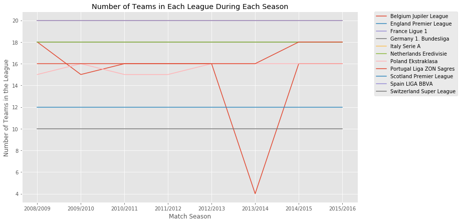

```python
%matplotlib inline

#set ggplot style
plt.style.use('ggplot')


# plot data
fig, ax = plt.subplots(figsize=(12,7))

# use unstack()
Count_Team_League_Season.groupby(['Match_Season','League_Name']).sum()['Number_of_Home_Teams'].unstack().plot(ax=ax)
ax.set_xlabel('Match Season')
ax.set_ylabel('Number of Teams in the League')
plt.xticks(range(len(seasons)),seasons)
plt.legend(bbox_to_anchor=(1.05, 1), loc=2, borderaxespad=0.)
plt.title('Number of Teams in Each League During Each Season')
```

One interesting insight is that the number of teams in all leagues are constant during different seasons except for "Belgium Jupiler League" which seems to have fluctuating teams during different seasons.  
In 2013/2014 season there were only four teams, KAA Gent, KV Oostende, Lierse SK, Waasland-Beveren in Belgium Jupiler League.  
Poland Ekstraklasa and Portugal Liga ZON Sagres also have some fluctuations.

## Goals Scored in Each League During Each Season

```python
#Defining a function to determine win, lose, tie for home team
def home_match_result(row):

#          """" This function calculates the result of a match for home team.
#              Args:
#                  dataframename row(Pandas dataframe): .
#              Returns:
#                  a value representing the result (string).
#          """"

    if row['home_team_goal'] == row['away_team_goal']:
        val = 'Home_Tie'
    elif row['home_team_goal'] > row['away_team_goal']:
        val = 'Home_Win'
    else:
        val = 'Home_Loss'
    return val
```

```python
#Defining a function to determine win, lose, tie for away team
def away_match_result(row):

#          """" This function calculates the result of a match for away team.
#              Args:
#                  dataframename row(Pandas dataframe): .
#              Returns:
#                  a value representing the result (string).
#          """"

    if row['home_team_goal'] == row['away_team_goal']:
        val = 'Away_Tie'
    elif row['home_team_goal'] < row['away_team_goal']:
        val = 'Away_Win'
    else:
        val = 'Away_Loss'
    return val
```

```python
#Using the merging of Pandas dataframe instead of SQL query to join Match and League

Leagues_Matches = Match_df[Match_df.league_id.isin(League_df['id'])]
Leagues_Matches = Leagues_Matches[['id','league_id','home_team_api_id','away_team_api_id','home_team_goal','away_team_goal','season']]
Leagues_Matches["total_goals"] = Leagues_Matches['home_team_goal'] + Leagues_Matches['away_team_goal']
Leagues_Matches["home_result"] = Leagues_Matches.apply(home_match_result,axis = 1)
Leagues_Matches["away_result"] = Leagues_Matches.apply(away_match_result,axis = 1)
Leagues_Matches.dropna(inplace=True)
Leagues_Matches.head()
```

|  | id | league_id | home_team_api_id | away_team_api_id | home_team_goal | away_team_goal | season | total_goals | home_result | away_result |
| --- | --- | --- | --- | --- | --- | --- | --- | --- | --- | --- |
| 0 | 1 | 1 | 9987 | 9993 | 1 | 1 | 2008/2009 | 2 | Home_Tie | Away_Tie |
| 1 | 2 | 1 | 10000 | 9994 | 0 | 0 | 2008/2009 | 0 | Home_Tie | Away_Tie |
| 2 | 3 | 1 | 9984 | 8635 | 0 | 3 | 2008/2009 | 3 | Home_Loss | Away_Win |
| 3 | 4 | 1 | 9991 | 9998 | 5 | 0 | 2008/2009 | 5 | Home_Win | Away_Loss |
| 4 | 5 | 1 | 7947 | 9985 | 1 | 3 | 2008/2009 | 4 | Home_Loss | Away_Win |

```python
#Separating the leagues for plotting and further analysis
Leagues_Matches_with_Results = pd.merge(Leagues_Matches,League_df,left_on='league_id', right_on='id')
Leagues_Matches_with_Results = Leagues_Matches_with_Results.drop(['id_x','id_y','country_id'],axis = 1)

Belgium_Jupiler_League = Leagues_Matches_with_Results[Leagues_Matches_with_Results.name == "Belgium Jupiler League"]
England_Premier_League = Leagues_Matches_with_Results[Leagues_Matches_with_Results.name == "England Premier League"]
France_Ligue = Leagues_Matches_with_Results[Leagues_Matches_with_Results.name == "France Ligue 1"]
Germany_Bundesliga = Leagues_Matches_with_Results[Leagues_Matches_with_Results.name == "Germany 1. Bundesliga"]
Italy_Serie_A = Leagues_Matches_with_Results[Leagues_Matches_with_Results.name == "Italy Serie A"]
Netherlands_Eredivisie = Leagues_Matches_with_Results[Leagues_Matches_with_Results.name == "Netherlands Eredivisie"]
Poland_Ekstraklasa = Leagues_Matches_with_Results[Leagues_Matches_with_Results.name == "Poland Ekstraklasa"]
Portugal_Liga_ZON_Sagres = Leagues_Matches_with_Results[Leagues_Matches_with_Results.name == "Portugal Liga ZON Sagres"]
Scotland_Premier_League = Leagues_Matches_with_Results[Leagues_Matches_with_Results.name == "Scotland Premier League"]
Spain_LIGA_BBVA = Leagues_Matches_with_Results[Leagues_Matches_with_Results.name == "Spain LIGA BBVA"]
Switzerland_Super_League = Leagues_Matches_with_Results[Leagues_Matches_with_Results.name == "Switzerland Super League"]

a = Belgium_Jupiler_League.groupby('season')
b = England_Premier_League.groupby('season')
c = France_Ligue.groupby('season')
d = Germany_Bundesliga.groupby('season')
e = Italy_Serie_A.groupby('season')
f = Netherlands_Eredivisie.groupby('season')
g = Poland_Ekstraklasa.groupby('season')
h = Portugal_Liga_ZON_Sagres.groupby('season')
i = Scotland_Premier_League.groupby('season')
j = Spain_LIGA_BBVA.groupby('season')
k = Switzerland_Super_League.groupby('season')
# seasons
```

```python
Leagues_Matches_with_Results.head()
```

|  | league_id | home_team_api_id | away_team_api_id | home_team_goal | away_team_goal | season | total_goals | home_result | away_result | name |
| --- | --- | --- | --- | --- | --- | --- | --- | --- | --- | --- |
| 0 | 1 | 9987 | 9993 | 1 | 1 | 2008/2009 | 2 | Home_Tie | Away_Tie | Belgium Jupiler League |
| 1 | 1 | 10000 | 9994 | 0 | 0 | 2008/2009 | 0 | Home_Tie | Away_Tie | Belgium Jupiler League |
| 2 | 1 | 9984 | 8635 | 0 | 3 | 2008/2009 | 3 | Home_Loss | Away_Win | Belgium Jupiler League |
| 3 | 1 | 9991 | 9998 | 5 | 0 | 2008/2009 | 5 | Home_Win | Away_Loss | Belgium Jupiler League |
| 4 | 1 | 7947 | 9985 | 1 | 3 | 2008/2009 | 4 | Home_Loss | Away_Win | Belgium Jupiler League |

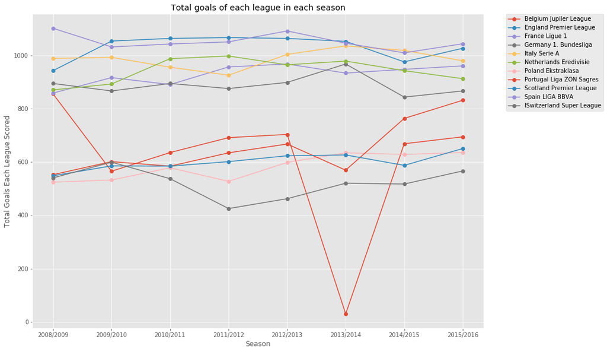

```python
#Plotting total goals scored each season
fig = plt.figure(figsize=(14, 10))
plt.title("Total goals of each league in each season")
plt.xticks(range(len(seasons)),seasons)
plt.style.use('ggplot')
plt.xlabel("Season")
plt.ylabel("Total Goals Each League Scored")
num_seasons = range(len(seasons))
plt.plot(num_seasons,a.total_goals.sum().values,label = "Belgium Jupiler League", marker = 'o')
plt.plot(num_seasons,b.total_goals.sum().values,label = "England Premier League", marker = 'o')
plt.plot(num_seasons,c.total_goals.sum().values,label = "France Ligue 1", marker = 'o')
plt.plot(num_seasons,d.total_goals.sum().values,label = "Germany 1. Bundesliga", marker = 'o')
plt.plot(num_seasons,e.total_goals.sum().values,label = "Italy Serie A", marker = 'o')
plt.plot(num_seasons,f.total_goals.sum().values,label = "Netherlands Eredivisie", marker = 'o')
plt.plot(num_seasons,g.total_goals.sum().values,label = "Poland Ekstraklasa", marker = 'o')
plt.plot(num_seasons,h.total_goals.sum().values,label = "Portugal Liga ZON Sagres", marker = 'o')
plt.plot(num_seasons,i.total_goals.sum().values,label = "Scotland Premier League", marker = 'o')
plt.plot(num_seasons,j.total_goals.sum().values,label = "Spain LIGA BBVA", marker = 'o')
plt.plot(num_seasons,k.total_goals.sum().values,label = "ISwitzerland Super League", marker = 'o')
plt.legend(bbox_to_anchor=(1.05, 1), loc=2, borderaxespad=0.)
```

Since the number of games in each league during each season are different, it might make more sense to look at average goals per league per season instead of totals.

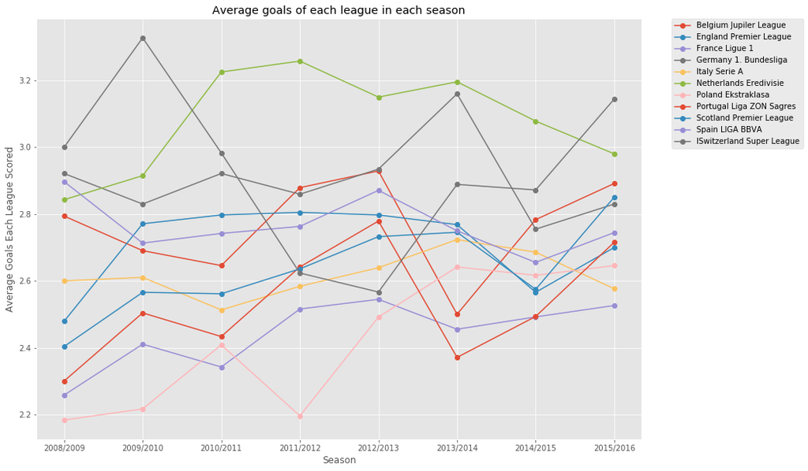

```python
#Plotting average goals scored each season
fig = plt.figure(figsize=(14, 10))
plt.title("Average goals of each league in each season")
plt.xticks(range(len(seasons)),seasons)
plt.style.use('ggplot')
plt.xlabel("Season")
plt.ylabel("Average Goals Each League Scored")
num_seasons = range(len(seasons))
plt.plot(num_seasons,a.total_goals.mean().values,label = "Belgium Jupiler League", marker = 'o')
plt.plot(num_seasons,b.total_goals.mean().values,label = "England Premier League", marker = 'o')
plt.plot(num_seasons,c.total_goals.mean().values,label = "France Ligue 1", marker = 'o')
plt.plot(num_seasons,d.total_goals.mean().values,label = "Germany 1. Bundesliga", marker = 'o')
plt.plot(num_seasons,e.total_goals.mean().values,label = "Italy Serie A", marker = 'o')
plt.plot(num_seasons,f.total_goals.mean().values,label = "Netherlands Eredivisie", marker = 'o')
plt.plot(num_seasons,g.total_goals.mean().values,label = "Poland Ekstraklasa", marker = 'o')
plt.plot(num_seasons,h.total_goals.mean().values,label = "Portugal Liga ZON Sagres", marker = 'o')
plt.plot(num_seasons,i.total_goals.mean().values,label = "Scotland Premier League", marker = 'o')
plt.plot(num_seasons,j.total_goals.mean().values,label = "Spain LIGA BBVA", marker = 'o')
plt.plot(num_seasons,k.total_goals.mean().values,label = "ISwitzerland Super League", marker = 'o')
plt.legend(bbox_to_anchor=(1.05, 1), loc=2, borderaxespad=0.)
```

When looking at averages, Netherlands Eredivisie seems to have the lead most seasons.

#### Is There a Home vs. Away Advantage When Looking at Goals Scored

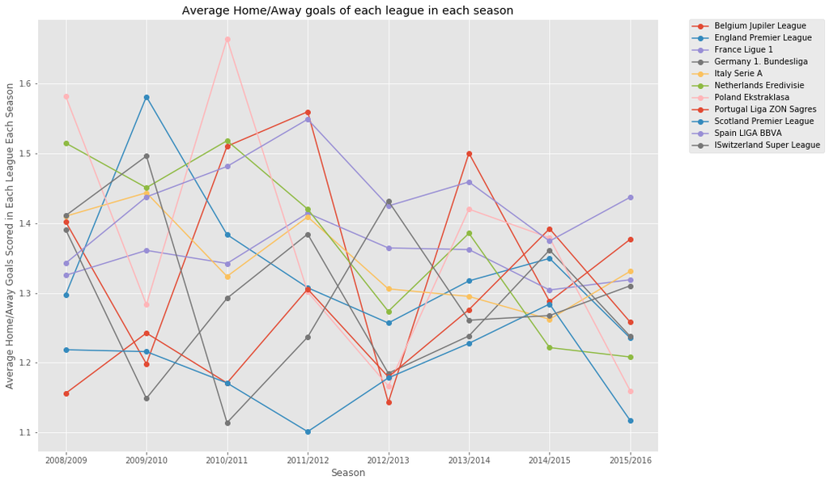

```python
#Plotting average home/away goals scored in each league each season
fig = plt.figure(figsize=(14, 10))
plt.title("Average Home/Away goals of each league in each season")
plt.xticks(range(len(seasons)),seasons)
plt.style.use('ggplot')
plt.xlabel("Season")
plt.ylabel("Average Home/Away Goals Scored in Each League Each Season")
num_seasons = range(len(seasons))
plt.plot(num_seasons,a.home_team_goal.mean().values / a.away_team_goal.mean().values,label = "Belgium Jupiler League", marker = 'o')
plt.plot(num_seasons,b.home_team_goal.mean().values / b.away_team_goal.mean().values,label = "England Premier League", marker = 'o')
plt.plot(num_seasons,c.home_team_goal.mean().values / c.away_team_goal.mean().values,label = "France Ligue 1", marker = 'o')
plt.plot(num_seasons,d.home_team_goal.mean().values / d.away_team_goal.mean().values,label = "Germany 1. Bundesliga", marker = 'o')
plt.plot(num_seasons,e.home_team_goal.mean().values / e.away_team_goal.mean().values,label = "Italy Serie A", marker = 'o')
plt.plot(num_seasons,f.home_team_goal.mean().values / f.away_team_goal.mean().values,label = "Netherlands Eredivisie", marker = 'o')
plt.plot(num_seasons,g.home_team_goal.mean().values / g.away_team_goal.mean().values,label = "Poland Ekstraklasa", marker = 'o')
plt.plot(num_seasons,h.home_team_goal.mean().values / h.away_team_goal.mean().values,label = "Portugal Liga ZON Sagres", marker = 'o')
plt.plot(num_seasons,i.home_team_goal.mean().values / i.away_team_goal.mean().values,label = "Scotland Premier League", marker = 'o')
plt.plot(num_seasons,j.home_team_goal.mean().values / j.away_team_goal.mean().values,label = "Spain LIGA BBVA", marker = 'o')
plt.plot(num_seasons,k.home_team_goal.mean().values / k.away_team_goal.mean().values,label = "ISwitzerland Super League", marker = 'o')
plt.legend(bbox_to_anchor=(1.05, 1), loc=2, borderaxespad=0.)
```

In the last five seasons, Spain LIGA teams seem to have a home advantage. This could be a key factor when they host teams from other leagues for European Leagues.  
In such championship matches, there are usually two fixtures played (home and away) by each team. And since goals scored in each of these fixtures plays a role in teams qualifying to the next round, there seems to a big advantage to the Spain LIGA teams in recent seasons.

The ratios for other leagues seem to vary significantly and not show any significant trends.

All the (home-goals/away-goals) ratios are above 1.1 and we can consistently see the ratio being above 1.2 for most leagues.  
This only shows that, on an average, teams score more at home fixtures than away. But how many of these matches do they win?

```python
#Looking into a very similar metric (average away-home goal difference), now using SQL query
Home_vs_Away_Goal_Diff = pd.read_sql("""SELECT Country.name AS country_name,
                                        League.name AS league_name,
                                        season,
                                        count(distinct stage) AS number_of_stages,
                                        count(distinct HT.team_long_name) AS number_of_teams,
                                        avg(home_team_goal) AS avg_home_team_goals,
                                        avg(away_team_goal) AS avg_away_team_goals,
                                        avg(home_team_goal-away_team_goal) AS avg_goal_dif,
                                        avg(home_team_goal+away_team_goal) AS avg_goals,
                                        sum(home_team_goal+away_team_goal) AS total_goals
                                FROM Match
                                JOIN Country on Country.id = Match.country_id
                                JOIN League on League.id = Match.league_id
                                LEFT JOIN Team AS HT on HT.team_api_id = Match.home_team_api_id
                                LEFT JOIN Team AS AT on AT.team_api_id = Match.away_team_api_id
                                GROUP BY Country.name, League.name, season
                                ORDER BY Country.name, League.name, season DESC
                                ;""", conn)
Home_vs_Away_Goal_Diff.head()
```

|  | country_name | league_name | season | number_of_stages | number_of_teams | avg_home_team_goals | avg_away_team_goals | avg_goal_dif | avg_goals | total_goals |
| --- | --- | --- | --- | --- | --- | --- | --- | --- | --- | --- |
| 0 | Belgium | Belgium Jupiler League | 2015/2016 | 30 | 16 | 1.675000 | 1.216667 | 0.458333 | 2.891667 | 694 |
| 1 | Belgium | Belgium Jupiler League | 2014/2015 | 30 | 16 | 1.566667 | 1.216667 | 0.350000 | 2.783333 | 668 |
| 2 | Belgium | Belgium Jupiler League | 2013/2014 | 6 | 4 | 1.500000 | 1.000000 | 0.500000 | 2.500000 | 30 |
| 3 | Belgium | Belgium Jupiler League | 2012/2013 | 30 | 16 | 1.562500 | 1.366667 | 0.195833 | 2.929167 | 703 |
| 4 | Belgium | Belgium Jupiler League | 2011/2012 | 30 | 16 | 1.754167 | 1.125000 | 0.629167 | 2.879167 | 691 |

```
Text(0.5,1,'Average Home-Away goal difference of each league in each season')
```

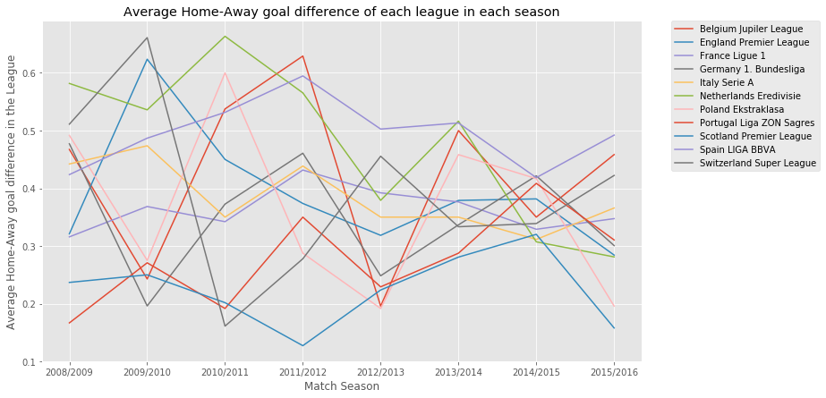

```python
#set ggplot style
plt.style.use('ggplot')


# plot data
fig, ax = plt.subplots(figsize=(12,7))

# use unstack()
Home_vs_Away_Goal_Diff.groupby(['season','league_name']).sum()['avg_goal_dif'].unstack().plot(ax=ax)
ax.set_xlabel('Match Season')
ax.set_ylabel('Average Home-Away goal difference in the League')
plt.xticks(range(len(seasons)),seasons)
plt.legend(bbox_to_anchor=(1.05, 1), loc=2, borderaxespad=0.)
plt.title('Average Home-Away goal difference of each league in each season')
```

#### What if we limit the countries? Are the trends more obvious.

```python
#Only looking at 'Spain', 'Germany', 'France', 'Italy', 'England'
Home_vs_Away_Goal_Diff_Top_Five = pd.read_sql("""SELECT Country.name AS country_name,
                                        League.name AS league_name,
                                        season,
                                        count(distinct stage) AS number_of_stages,
                                        count(distinct HT.team_long_name) AS number_of_teams,
                                        avg(home_team_goal) AS avg_home_team_goals,
                                        avg(away_team_goal) AS avg_away_team_goals,
                                        avg(home_team_goal-away_team_goal) AS avg_goal_dif,
                                        avg(home_team_goal+away_team_goal) AS avg_goals,
                                        sum(home_team_goal+away_team_goal) AS total_goals
                                FROM Match
                                JOIN Country on Country.id = Match.country_id
                                JOIN League on League.id = Match.league_id
                                LEFT JOIN Team AS HT on HT.team_api_id = Match.home_team_api_id
                                LEFT JOIN Team AS AT on AT.team_api_id = Match.away_team_api_id
                                WHERE country_name in ('Spain', 'Germany', 'France', 'Italy', 'England')
                                GROUP BY Country.name, League.name, season
                                HAVING count(distinct stage) > 10
                                ORDER BY Country.name, League.name, season DESC
                                ;""", conn)
Home_vs_Away_Goal_Diff_Top_Five.head()
```

|  | country_name | league_name | season | number_of_stages | number_of_teams | avg_home_team_goals | avg_away_team_goals | avg_goal_dif | avg_goals | total_goals |
| --- | --- | --- | --- | --- | --- | --- | --- | --- | --- | --- |
| 0 | England | England Premier League | 2015/2016 | 38 | 20 | 1.492105 | 1.207895 | 0.284211 | 2.700000 | 1026 |
| 1 | England | England Premier League | 2014/2015 | 38 | 20 | 1.473684 | 1.092105 | 0.381579 | 2.565789 | 975 |
| 2 | England | England Premier League | 2013/2014 | 38 | 20 | 1.573684 | 1.194737 | 0.378947 | 2.768421 | 1052 |
| 3 | England | England Premier League | 2012/2013 | 38 | 20 | 1.557895 | 1.239474 | 0.318421 | 2.797368 | 1063 |
| 4 | England | England Premier League | 2011/2012 | 38 | 20 | 1.589474 | 1.215789 | 0.373684 | 2.805263 | 1066 |

```
Text(0.5,1,'Average Home-Away goal difference of each league in each season')
```

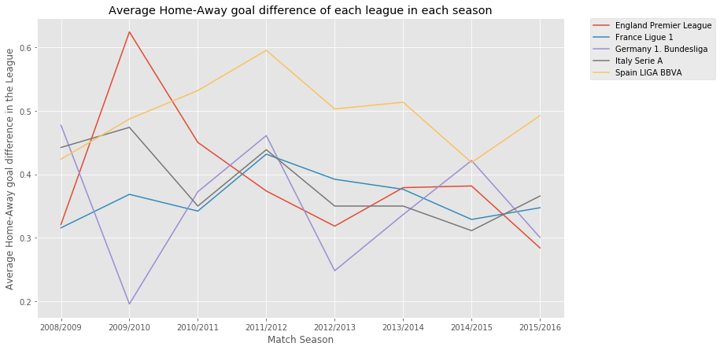

```python
#Only looking at 'Spain', 'Germany', 'France', 'Italy', 'England'
#set ggplot style
plt.style.use('ggplot')


# plot data
fig, ax = plt.subplots(figsize=(12,7))

# use unstack()
Home_vs_Away_Goal_Diff_Top_Five.groupby(['season','league_name']).sum()['avg_goal_dif'].unstack().plot(ax=ax)
ax.set_xlabel('Match Season')
ax.set_ylabel('Average Home-Away goal difference in the League')
plt.xticks(range(len(seasons)),seasons)
plt.legend(bbox_to_anchor=(1.05, 1), loc=2, borderaxespad=0.)
plt.title('Average Home-Away goal difference of each league in each season')
```

This is cleaner and easier to interpret.  
In the last five seasons, Spain LIGA teams has a strong home advantage.  
Germany Bundesliga keeps oscillating between a strong home game and weak home game season.

- How was the performance (home win, home tiem home loss, away win, away loss, away tie) of teams in each league during each season?  
- How to quantify the performance in terms of match results?

## How was each Team's Victory/Performance in Each League Each Season

```python
#Merging home team and team dataframe to get teams and leagues
Home_Teams_df = Leagues_Matches_with_Results[['home_team_api_id', 'season', 'home_result', 'name']]
Home_Teams_Names_df = pd.merge(Home_Teams_df,Team_df,left_on='home_team_api_id', right_on='team_api_id')
Home_Teams_Names_df = Home_Teams_Names_df.drop(['id','home_team_api_id','team_fifa_api_id', 'team_short_name'],axis = 1)
Home_Teams_Names_df.columns = ['season', 'game_result', 'league','team_api_id', 'team_name']
Home_Teams_Names_df.head()
```

|  | season | game_result | league | team_api_id | team_name |
| --- | --- | --- | --- | --- | --- |
| 0 | 2008/2009 | Home_Tie | Belgium Jupiler League | 9987 | KRC Genk |
| 1 | 2008/2009 | Home_Tie | Belgium Jupiler League | 9987 | KRC Genk |
| 2 | 2008/2009 | Home_Win | Belgium Jupiler League | 9987 | KRC Genk |
| 3 | 2008/2009 | Home_Win | Belgium Jupiler League | 9987 | KRC Genk |
| 4 | 2008/2009 | Home_Win | Belgium Jupiler League | 9987 | KRC Genk |

```python
#Merging away team and team dataframe to get teams and leagues
Away_Teams_df = Leagues_Matches_with_Results[['away_team_api_id', 'season', 'away_result', 'name']]
Away_Teams_Names_df = pd.merge(Away_Teams_df,Team_df,left_on='away_team_api_id', right_on='team_api_id')
Away_Teams_Names_df = Away_Teams_Names_df.drop(['id','away_team_api_id','team_fifa_api_id', 'team_short_name'],axis = 1)
Away_Teams_Names_df.columns = ['season', 'game_result', 'league','team_api_id', 'team_name']
Away_Teams_Names_df.head()
```

|  | season | game_result | league | team_api_id | team_name |
| --- | --- | --- | --- | --- | --- |
| 0 | 2008/2009 | Away_Tie | Belgium Jupiler League | 9993 | Beerschot AC |
| 1 | 2008/2009 | Away_Tie | Belgium Jupiler League | 9993 | Beerschot AC |
| 2 | 2008/2009 | Away_Loss | Belgium Jupiler League | 9993 | Beerschot AC |
| 3 | 2008/2009 | Away_Loss | Belgium Jupiler League | 9993 | Beerschot AC |
| 4 | 2008/2009 | Away_Win | Belgium Jupiler League | 9993 | Beerschot AC |

```python
#Combining home and away teams to get all teams and leagues
Teams_Results_Names = Home_Teams_Names_df.append(Away_Teams_Names_df)
```

```python
Teams_Results_Names.head()
```

|  | season | game_result | league | team_api_id | team_name |
| --- | --- | --- | --- | --- | --- |
| 0 | 2008/2009 | Home_Tie | Belgium Jupiler League | 9987 | KRC Genk |
| 1 | 2008/2009 | Home_Tie | Belgium Jupiler League | 9987 | KRC Genk |
| 2 | 2008/2009 | Home_Win | Belgium Jupiler League | 9987 | KRC Genk |
| 3 | 2008/2009 | Home_Win | Belgium Jupiler League | 9987 | KRC Genk |
| 4 | 2008/2009 | Home_Win | Belgium Jupiler League | 9987 | KRC Genk |

#### Defining a function for performance based on the following scoring method:

```python
#Function that assigns a score to the performance of the team depending on match results

def team_performance(value):

#          """" This function calculates a performance score based on the match results. {"Home loss"=-2, "Home tie"=0,
#               "Home win=1, "Away loss"=-1, "Away tie"=1,"Away win=2, "}
#              Args:
#                  a single match result value (string) .
#              Returns:
#                  a value representing the performance score (integer).
#          """"

    if value == "Home_loss":
        performace = -2
    elif value == "Home_Tie":
        performance = 0
    elif value == "Home_Win":
        performance = 1
    elif value == "Away_Loss":
        performance = -1
    elif value == "Away_Tie":
        performance = 1
    else:
        performance = 2
    return performance

print (team_performance("Away_Win"))
```

```
2
```

```python
#Now that the function is working, we will apply the function to the column "game_result"
Teams_Results_Names["Team_Performance"] = Teams_Results_Names['game_result'].apply(team_performance)
Teams_Results_Names.dropna(inplace=True)
Teams_Results_Names.head()
```

|  | season | game_result | league | team_api_id | team_name | Team_Performance |
| --- | --- | --- | --- | --- | --- | --- |
| 0 | 2008/2009 | Home_Tie | Belgium Jupiler League | 9987 | KRC Genk | 0 |
| 1 | 2008/2009 | Home_Tie | Belgium Jupiler League | 9987 | KRC Genk | 0 |
| 2 | 2008/2009 | Home_Win | Belgium Jupiler League | 9987 | KRC Genk | 1 |
| 3 | 2008/2009 | Home_Win | Belgium Jupiler League | 9987 | KRC Genk | 1 |
| 4 | 2008/2009 | Home_Win | Belgium Jupiler League | 9987 | KRC Genk | 1 |

```python
Team_Performance = """SELECT
        t.team_name AS Team_Name, t.season AS Season, sum(t.Team_Performance) AS Team_Performance, league as League
     FROM
        Teams_Results_Names t
     GROUP BY t.team_name, t.season
     ORDER BY Season, Team_Performance, Team_Name DESC
           ;"""
Team_Performance_df = sqldf(Team_Performance)
Team_Performance_df.head()
```

|  | Team_Name | Season | Team_Performance | League |
| --- | --- | --- | --- | --- |
| 0 | RAEC Mons | 2008/2009 | 6 | Belgium Jupiler League |
| 1 | Middlesbrough | 2008/2009 | 6 | England Premier League |
| 2 | Cracovia | 2008/2009 | 6 | Poland Ekstraklasa |
| 3 | Hannover 96 | 2008/2009 | 7 | Germany 1. Bundesliga |
| 4 | Heracles Almelo | 2008/2009 | 8 | Netherlands Eredivisie |

```python
Season_One_Top_Ten = """SELECT
            Team_Name, Season, Team_Performance, League
         FROM
            Team_Performance_df t
         WHERE t.Season = '2008/2009'
         ORDER BY Team_Performance DESC
         LIMIT 10
               ;"""
Season_One_Top_Ten_df = sqldf(Season_One_Top_Ten)
Season_Two_Top_Ten = """SELECT
            Team_Name, Season, Team_Performance, League
         FROM
            Team_Performance_df t
         WHERE t.Season = '2009/2010'
         ORDER BY Team_Performance DESC
         LIMIT 10
               ;"""
Season_Two_Top_Ten_df = sqldf(Season_Two_Top_Ten)
Season_Three_Top_Ten = """SELECT
            Team_Name, Season, Team_Performance, League
         FROM
            Team_Performance_df t
         WHERE t.Season = '2010/2011'
         ORDER BY Team_Performance DESC
         LIMIT 10
               ;"""
Season_Three_Top_Ten_df = sqldf(Season_Three_Top_Ten)
Season_Four_Top_Ten = """SELECT
            Team_Name, Season, Team_Performance, League
         FROM
            Team_Performance_df t
         WHERE t.Season = '2011/2012'
         ORDER BY Team_Performance DESC
         LIMIT 10
               ;"""
Season_Four_Top_Ten_df = sqldf(Season_Four_Top_Ten)
Season_Five_Top_Ten = """SELECT
            Team_Name, Season, Team_Performance, League
         FROM
            Team_Performance_df t
         WHERE t.Season = '2012/2013'
         ORDER BY Team_Performance DESC
         LIMIT 10
               ;"""
Season_Five_Top_Ten_df = sqldf(Season_Five_Top_Ten)
Season_Six_Top_Ten = """SELECT
            Team_Name, Season, Team_Performance, League
         FROM
            Team_Performance_df t
         WHERE t.Season = '2013/2014'
         ORDER BY Team_Performance DESC
         LIMIT 10
               ;"""
Season_Six_Top_Ten_df = sqldf(Season_Six_Top_Ten)
Season_Seven_Top_Ten = """SELECT
            Team_Name, Season, Team_Performance, League
         FROM
            Team_Performance_df t
         WHERE t.Season = '2014/2015'
         ORDER BY Team_Performance DESC
         LIMIT 10
               ;"""
Season_Seven_Top_Ten_df = sqldf(Season_Seven_Top_Ten)
Season_Eight_Top_Ten = """SELECT
            Team_Name, Season, Team_Performance, League
         FROM
            Team_Performance_df t
         WHERE t.Season = '2015/2016'
         ORDER BY Team_Performance DESC
         LIMIT 10
               ;"""
Season_Eight_Top_Ten_df = sqldf(Season_Eight_Top_Ten)
Season_Three_Top_Ten_df
```

|  | Team_Name | Season | Team_Performance | League |
| --- | --- | --- | --- | --- |
| 0 | Rangers | 2010/2011 | 51 | Scotland Premier League |
| 1 | FC Barcelona | 2010/2011 | 49 | Spain LIGA BBVA |
| 2 | Real Madrid CF | 2010/2011 | 48 | Spain LIGA BBVA |
| 3 | Celtic | 2010/2011 | 44 | Scotland Premier League |
| 4 | Milan | 2010/2011 | 43 | Italy Serie A |
| 5 | FC Porto | 2010/2011 | 42 | Portugal Liga ZON Sagres |
| 6 | Inverness Caledonian Thistle | 2010/2011 | 39 | Scotland Premier League |
| 7 | 1. FSV Mainz 05 | 2010/2011 | 39 | Germany 1. Bundesliga |
| 8 | Valencia CF | 2010/2011 | 38 | Spain LIGA BBVA |
| 9 | Kilmarnock | 2010/2011 | 38 | Scotland Premier League |

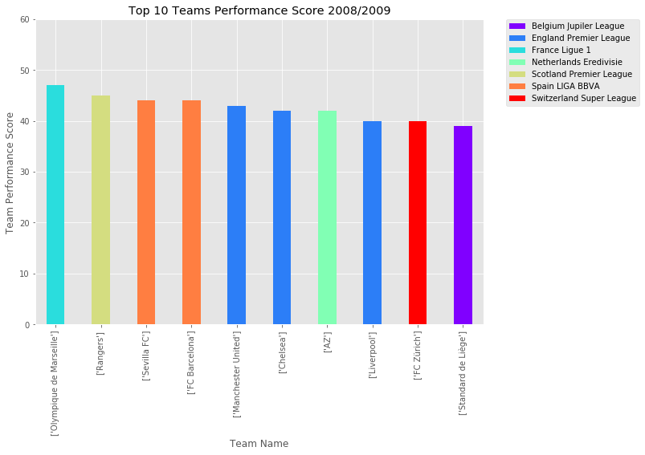

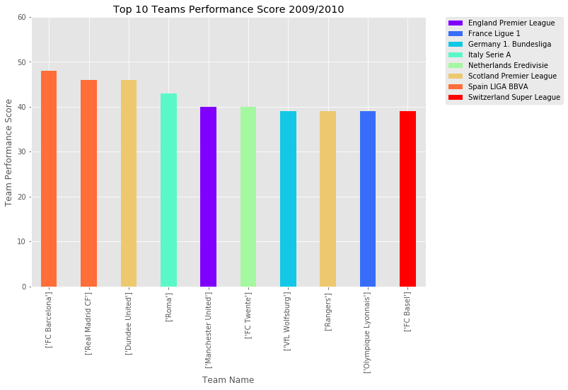

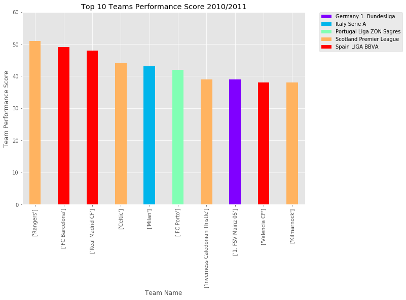

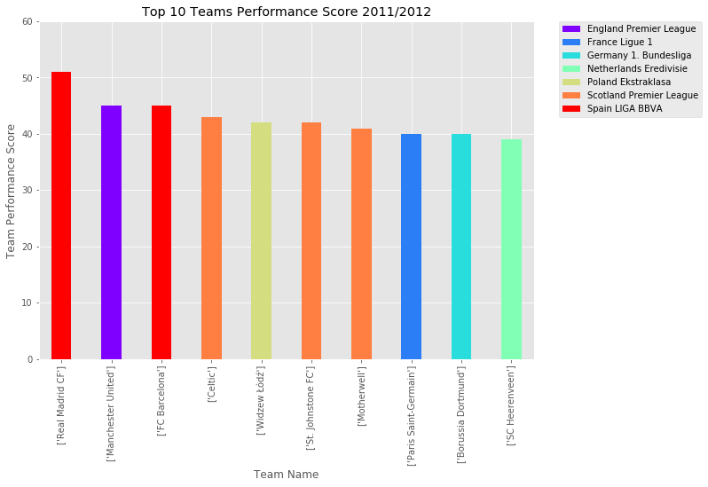

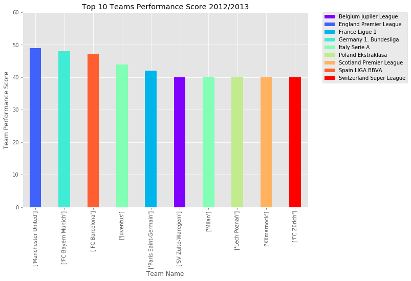

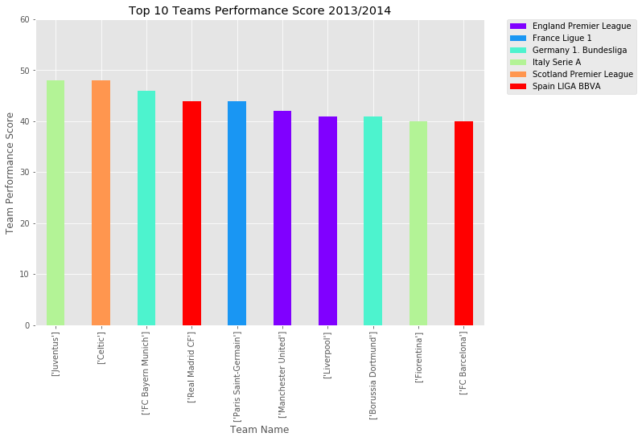

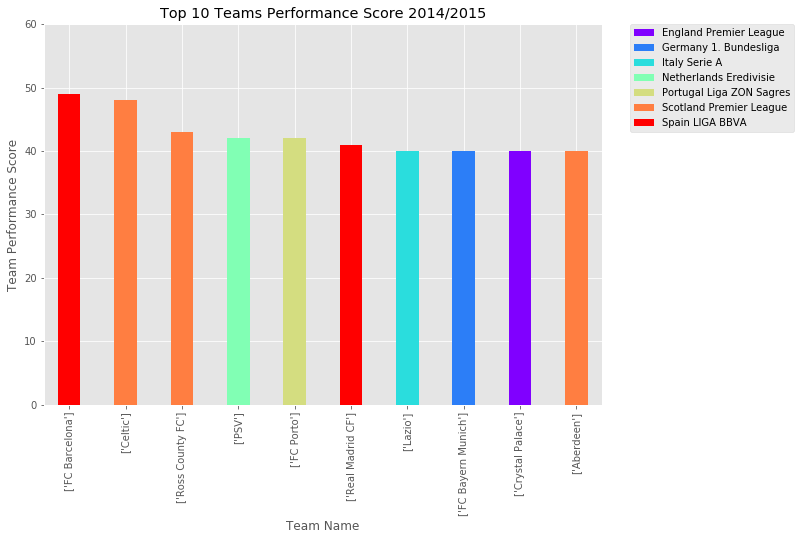

[figure not shown]

```python
###Plotting all eight seasons

###2008-2009
# Empty list to append later
grouped_list_One = []
label_list_One = []

# Iterating through each group key grouped by league
for label, key in Season_One_Top_Ten_df.groupby(['League'])['Team_Performance']:
    grouped_list_One.append(key)
    label_list_One.append(label)

# Concatenating the grouped list column-wise and filling Nans with 0's
df_grouped_bar_One = pd.concat(grouped_list_One, axis=1).fillna(0)

# Renaming columns created to take on new names
df_grouped_bar_One.columns = label_list_One

# Bar plot with a chosen colormap
ax1 = df_grouped_bar_One.plot(kind='bar', stacked=True, figsize=(10,7),
                         width=0.4, ylim=(0,60), cmap=plt.cm.rainbow)
# Figure Aesthetics
ax1.set_xticklabels(np.array((Season_One_Top_Ten_df[['Team_Name']].values)))
ax1.set_ylabel('Team Performance Score')
ax1.set_xlabel('Team Name')
ax1.set_title("Top 10 Teams Performance Score 2008/2009")
ax1.legend(label_list_One)
ax1.legend(label_list_One, bbox_to_anchor=(1.05, 1), loc=2, borderaxespad=0.)


###2009-2010
# Empty list to append later
grouped_list_Two = []
label_list_Two = []

# Iterating through each group key grouped by league
for label, key in Season_Two_Top_Ten_df.groupby(['League'])['Team_Performance']:
    grouped_list_Two.append(key)
    label_list_Two.append(label)

# Concatenating the grouped list column-wise and filling Nans with 0's
df_grouped_bar_Two = pd.concat(grouped_list_Two, axis=1).fillna(0)

# Renaming columns created to take on new names
df_grouped_bar_Two.columns = label_list_Two

# Bar plot with a chosen colormap
ax2 = df_grouped_bar_Two.plot(kind='bar', stacked=True, figsize=(10,7),
                         width=0.4, ylim=(0,60), cmap=plt.cm.rainbow)
# Figure Aesthetics
ax2.set_xticklabels(np.array((Season_Two_Top_Ten_df[['Team_Name']].values)))
ax2.set_ylabel('Team Performance Score')
ax2.set_xlabel('Team Name')
ax2.set_title("Top 10 Teams Performance Score 2009/2010")
ax2.legend(label_list_Two)
ax2.legend(label_list_Two, bbox_to_anchor=(1.05, 1), loc=2, borderaxespad=0.)


###2010-2011
# Empty list to append later
grouped_list_Three = []
label_list_Three = []

# Iterating through each group key grouped by league
for label, key in Season_Three_Top_Ten_df.groupby(['League'])['Team_Performance']:
    grouped_list_Three.append(key)
    label_list_Three.append(label)

# Concatenating the grouped list column-wise and filling Nans with 0's
df_grouped_bar_Three = pd.concat(grouped_list_Three, axis=1).fillna(0)

# Renaming columns created to take on new names
df_grouped_bar_Three.columns = label_list_Three

# Bar plot with a chosen colormap
ax3 = df_grouped_bar_Three.plot(kind='bar', stacked=True, figsize=(10,7),
                         width=0.4, ylim=(0,60), cmap=plt.cm.rainbow)
# Figure Aesthetics
ax3.set_xticklabels(np.array((Season_Three_Top_Ten_df[['Team_Name']].values)))
ax3.set_ylabel('Team Performance Score')
ax3.set_xlabel('Team Name')
ax3.set_title("Top 10 Teams Performance Score 2010/2011")
ax3.legend(label_list_Three)
ax3.legend(label_list_Three, bbox_to_anchor=(1.05, 1), loc=2, borderaxespad=0.)


###2011-2012
# Empty list to append later
grouped_list_Four = []
label_list_Four = []

# Iterating through each group key grouped by league
for label, key in Season_Four_Top_Ten_df.groupby(['League'])['Team_Performance']:
    grouped_list_Four.append(key)
    label_list_Four.append(label)

# Concatenating the grouped list column-wise and filling Nans with 0's
df_grouped_bar_Four = pd.concat(grouped_list_Four, axis=1).fillna(0)

# Renaming columns created to take on new names
df_grouped_bar_Four.columns = label_list_Four

# Bar plot with a chosen colormap
ax4 = df_grouped_bar_Four.plot(kind='bar', stacked=True, figsize=(10,7),
                         width=0.4, ylim=(0,60), cmap=plt.cm.rainbow)
# Figure Aesthetics
ax4.set_xticklabels(np.array((Season_Four_Top_Ten_df[['Team_Name']].values)))
ax4.set_ylabel('Team Performance Score')
ax4.set_xlabel('Team Name')
ax4.set_title("Top 10 Teams Performance Score 2011/2012")
ax4.legend(label_list_Four)
ax4.legend(label_list_Four, bbox_to_anchor=(1.05, 1), loc=2, borderaxespad=0.)


###2012-2013
# Empty list to append later
grouped_list_Five = []
label_list_Five = []

# Iterating through each group key grouped by league
for label, key in Season_Five_Top_Ten_df.groupby(['League'])['Team_Performance']:
    grouped_list_Five.append(key)
    label_list_Five.append(label)

# Concatenating the grouped list column-wise and filling Nans with 0's
df_grouped_bar_Five = pd.concat(grouped_list_Five, axis=1).fillna(0)

# Renaming columns created to take on new names
df_grouped_bar_Five.columns = label_list_Five

# Bar plot with a chosen colormap
ax5 = df_grouped_bar_Five.plot(kind='bar', stacked=True, figsize=(10,7),
                         width=0.4, ylim=(0,60), cmap=plt.cm.rainbow)
# Figure Aesthetics
ax5.set_xticklabels(np.array((Season_Five_Top_Ten_df[['Team_Name']].values)))
ax5.set_ylabel('Team Performance Score')
ax5.set_xlabel('Team Name')
ax5.set_title("Top 10 Teams Performance Score 2012/2013")
ax5.legend(label_list_Five)
ax5.legend(label_list_Five, bbox_to_anchor=(1.05, 1), loc=2, borderaxespad=0.)


###2013-2014
# Empty list to append later
grouped_list_Six = []
label_list_Six = []

# Iterating through each group key grouped by league
for label, key in Season_Six_Top_Ten_df.groupby(['League'])['Team_Performance']:
    grouped_list_Six.append(key)
    label_list_Six.append(label)

# Concatenating the grouped list column-wise and filling Nans with 0's
df_grouped_bar_Six = pd.concat(grouped_list_Six, axis=1).fillna(0)

# Renaming columns created to take on new names
df_grouped_bar_Six.columns = label_list_Six

# Bar plot with a chosen colormap
ax6 = df_grouped_bar_Six.plot(kind='bar', stacked=True, figsize=(10,7),
                         width=0.4, ylim=(0,60), cmap=plt.cm.rainbow)
# Figure Aesthetics
ax6.set_xticklabels(np.array((Season_Six_Top_Ten_df[['Team_Name']].values)))
ax6.set_ylabel('Team Performance Score')
ax6.set_xlabel('Team Name')
ax6.set_title("Top 10 Teams Performance Score 2013/2014")
ax6.legend(label_list_Six)
ax6.legend(label_list_Six, bbox_to_anchor=(1.05, 1), loc=2, borderaxespad=0.)

###2014-2015
# Empty list to append later
grouped_list_Seven = []
label_list_Seven = []

# Iterating through each group key grouped by league
for label, key in Season_Seven_Top_Ten_df.groupby(['League'])['Team_Performance']:
    grouped_list_Seven.append(key)
    label_list_Seven.append(label)

# Concatenating the grouped list column-wise and filling Nans with 0's
df_grouped_bar_Seven = pd.concat(grouped_list_Seven, axis=1).fillna(0)

# Renaming columns created to take on new names
df_grouped_bar_Seven.columns = label_list_Seven

# Bar plot with a chosen colormap
ax7 = df_grouped_bar_Seven.plot(kind='bar', stacked=True, figsize=(10,7),
                         width=0.4, ylim=(0,60), cmap=plt.cm.rainbow)
# Figure Aesthetics
ax7.set_xticklabels(np.array((Season_Seven_Top_Ten_df[['Team_Name']].values)))
ax7.set_ylabel('Team Performance Score')
ax7.set_xlabel('Team Name')
ax7.set_title("Top 10 Teams Performance Score 2014/2015")
ax7.legend(label_list_Seven)
ax7.legend(label_list_Seven, bbox_to_anchor=(1.05, 1), loc=2, borderaxespad=0.)


###2015-2016
# Empty list to append later
grouped_list_Eight = []
label_list_Eight = []

# Iterating through each group key grouped by league
for label, key in Season_Eight_Top_Ten_df.groupby(['League'])['Team_Performance']:
    grouped_list_Eight.append(key)
    label_list_Eight.append(label)

# Concatenating the grouped list column-wise and filling Nans with 0's
df_grouped_bar_Eight = pd.concat(grouped_list_Eight, axis=1).fillna(0)

# Renaming columns created to take on new names
df_grouped_bar_Eight.columns = label_list_Eight

# Bar plot with a chosen colormap
ax8 = df_grouped_bar_Eight.plot(kind='bar', stacked=True, figsize=(10,7),
                         width=0.4, ylim=(0,60), cmap=plt.cm.rainbow)
# Figure Aesthetics
ax8.set_xticklabels(np.array((Season_Eight_Top_Ten_df[['Team_Name']].values)))
ax8.set_ylabel('Team Performance Score')
ax8.set_xlabel('Team Name')
ax8.set_title("Top 10 Teams Performance Score 2014/2015")
ax8.legend(label_list_Eight)
ax8.legend(label_list_Eight, bbox_to_anchor=(1.05, 1), loc=2, borderaxespad=0.)

plt.show()
```

As seen from previous results, Spain LIGA BBVA seems to be pretty strong appearing in top ten in every season. Its two star teams are Real Madrid CF and FC Barcelona.  
Another interesting observation is that some seasons are less competetive. For example, 2010-2011 only five teams had the top ten teams.

## What Leagues Had the Top Performance Team Most Frequently Over All Seasons

```python
#Joining all dataframes with top ten teams from all eight seasons
Joined_Top_Tens_All_Seasons = [Season_One_Top_Ten_df, Season_Two_Top_Ten_df, Season_Three_Top_Ten_df,\
                              Season_Four_Top_Ten_df, Season_Five_Top_Ten_df, Season_Six_Top_Ten_df,\
                              Season_Seven_Top_Ten_df, Season_Eight_Top_Ten_df]
Joined_Top_Tens_All_Seasons_df = pd.concat(Joined_Top_Tens_All_Seasons)
```

```python
Joined_Top_Tens_All_Seasons_df.head()
```

|  | Team_Name | Season | Team_Performance | League |
| --- | --- | --- | --- | --- |
| 0 | Olympique de Marseille | 2008/2009 | 47 | France Ligue 1 |
| 1 | Rangers | 2008/2009 | 45 | Scotland Premier League |
| 2 | Sevilla FC | 2008/2009 | 44 | Spain LIGA BBVA |
| 3 | FC Barcelona | 2008/2009 | 44 | Spain LIGA BBVA |
| 4 | Manchester United | 2008/2009 | 43 | England Premier League |

```python
#With this query we get a table that gets the number of times each league had its teams in the top ten performers
League_Performance = """SELECT
            League, COUNT(League) AS Times_in_Top_Ten
         FROM
            Joined_Top_Tens_All_Seasons_df
         GROUP BY League
         ORDER BY Times_in_Top_Ten DESC
               ;"""
League_Performance_df = sqldf(League_Performance)
League_Performance_df
```

|  | League | Times_in_Top_Ten |
| --- | --- | --- |
| 0 | Spain LIGA BBVA | 16 |
| 1 | Scotland Premier League | 15 |
| 2 | England Premier League | 9 |
| 3 | Germany 1. Bundesliga | 8 |
| 4 | Italy Serie A | 8 |
| 5 | France Ligue 1 | 6 |
| 6 | Netherlands Eredivisie | 6 |
| 7 | Portugal Liga ZON Sagres | 4 |
| 8 | Switzerland Super League | 4 |
| 9 | Belgium Jupiler League | 2 |
| 10 | Poland Ekstraklasa | 2 |

Spain LIGA BBVA is the leader by having 16 teams in top ten from 2008 to 2016 followed closely by Scotland Premier League .

- Which players had the most penalties?  
- What player attributes lead to the most potential?  
- Correlation between some player attributes and player potential.

```python
#With this query we get a table that gets the number of times each league had its teams in the top ten performers
Player_Penalties = """SELECT
            p.player_name AS Name, SUM(penalties) AS Total_Penalties
         FROM
            Player_df p
         INNER JOIN Player_Attributes_df a
         ON p.player_api_id=a.player_api_id
         GROUP BY p.player_name
         ORDER BY Total_Penalties DESC
         LIMIT 10
               ;"""
Player_Penalties_df = sqldf(Player_Penalties)
Player_Penalties_df
```

|  | Name | Total_Penalties |
| --- | --- | --- |
| 0 | Danilo | 6358.0 |
| 1 | Alex | 6140.0 |
| 2 | Fernando | 4764.0 |
| 3 | Douglas | 4687.0 |
| 4 | Josue | 4671.0 |
| 5 | Rafinha | 4633.0 |
| 6 | Alessio Cerci | 4314.0 |
| 7 | Carlos Eduardo | 4306.0 |
| 8 | Maicon | 4263.0 |
| 9 | Diego | 4259.0 |

Danilo has had the most penalties.

## What player attributes lead to the most potential?

```python
Player_Attributes_df.head()
```

|  | id | player_fifa_api_id | player_api_id | date | overall_rating | potential | preferred_foot | attacking_work_rate | defensive_work_rate | crossing | ... | vision | penalties | marking | standing_tackle | sliding_tackle | gk_diving | gk_handling | gk_kicking | gk_positioning | gk_reflexes |
| --- | --- | --- | --- | --- | --- | --- | --- | --- | --- | --- | --- | --- | --- | --- | --- | --- | --- | --- | --- | --- | --- |
| 0 | 1 | 218353 | 505942 | 2016-02-18 00:00:00 | 67.0 | 71.0 | right | medium | medium | 49.0 | ... | 54.0 | 48.0 | 65.0 | 69.0 | 69.0 | 6.0 | 11.0 | 10.0 | 8.0 | 8.0 |
| 1 | 2 | 218353 | 505942 | 2015-11-19 00:00:00 | 67.0 | 71.0 | right | medium | medium | 49.0 | ... | 54.0 | 48.0 | 65.0 | 69.0 | 69.0 | 6.0 | 11.0 | 10.0 | 8.0 | 8.0 |
| 2 | 3 | 218353 | 505942 | 2015-09-21 00:00:00 | 62.0 | 66.0 | right | medium | medium | 49.0 | ... | 54.0 | 48.0 | 65.0 | 66.0 | 69.0 | 6.0 | 11.0 | 10.0 | 8.0 | 8.0 |
| 3 | 4 | 218353 | 505942 | 2015-03-20 00:00:00 | 61.0 | 65.0 | right | medium | medium | 48.0 | ... | 53.0 | 47.0 | 62.0 | 63.0 | 66.0 | 5.0 | 10.0 | 9.0 | 7.0 | 7.0 |
| 4 | 5 | 218353 | 505942 | 2007-02-22 00:00:00 | 61.0 | 65.0 | right | medium | medium | 48.0 | ... | 53.0 | 47.0 | 62.0 | 63.0 | 66.0 | 5.0 | 10.0 | 9.0 | 7.0 | 7.0 |

5 rows × 42 columns

```python
players_height = pd.read_sql("""SELECT CASE
                                        WHEN ROUND(height)<165 then 165
                                        WHEN ROUND(height)>195 then 195
                                        ELSE ROUND(height)
                                        END AS calc_height,
                                        COUNT(height) AS distribution,
                                        (avg(PA_Grouped.avg_overall_rating)) AS avg_overall_rating,
                                        (avg(PA_Grouped.avg_potential)) AS avg_potential,
                                        (avg(PA_Grouped.avg_vision)) AS avg_vision,
                                        (avg(PA_Grouped.avg_penalties)) AS avg_penalties,
                                        AVG(weight) AS avg_weight
                            FROM PLAYER
                            LEFT JOIN (SELECT Player_Attributes.player_api_id,
                                        avg(Player_Attributes.overall_rating) AS avg_overall_rating,
                                        avg(Player_Attributes.vision) AS avg_vision,
                                        avg(Player_Attributes.potential) AS avg_potential,
                                        avg(Player_Attributes.penalties) AS avg_penalties
                                        FROM Player_Attributes
                                        GROUP BY Player_Attributes.player_api_id)
                                        AS PA_Grouped ON PLAYER.player_api_id = PA_Grouped.player_api_id
                            GROUP BY calc_height
                            ORDER BY calc_height
                                ;""", conn)
players_height
```

|  | calc_height | distribution | avg_overall_rating | avg_potential | avg_vision | avg_penalties | avg_weight |
| --- | --- | --- | --- | --- | --- | --- | --- |
| 0 | 165.0 | 74 | 67.365543 | 73.327754 | 64.490531 | 58.266138 | 139.459459 |
| 1 | 168.0 | 118 | 67.500518 | 73.124182 | 64.651771 | 57.905452 | 144.127119 |
| 2 | 170.0 | 403 | 67.726903 | 73.379056 | 63.533760 | 59.323296 | 147.799007 |
| 3 | 173.0 | 530 | 66.980272 | 72.848746 | 62.235208 | 58.093290 | 152.824528 |
| 4 | 175.0 | 1188 | 66.805204 | 72.258774 | 61.788592 | 57.804748 | 156.111953 |
| 5 | 178.0 | 1489 | 66.367212 | 71.943339 | 60.374228 | 57.038889 | 160.665547 |
| 6 | 180.0 | 1388 | 66.419053 | 71.846394 | 58.718348 | 55.641940 | 165.261527 |
| 7 | 183.0 | 1954 | 66.634380 | 71.754555 | 56.071072 | 54.111616 | 170.167861 |
| 8 | 185.0 | 1278 | 66.928964 | 71.833475 | 52.971930 | 51.698712 | 174.636933 |
| 9 | 188.0 | 1305 | 67.094253 | 72.151949 | 49.867048 | 49.099993 | 179.278161 |
| 10 | 191.0 | 652 | 66.997649 | 71.846159 | 45.926898 | 47.016138 | 184.791411 |
| 11 | 193.0 | 470 | 67.485141 | 72.459225 | 45.484934 | 46.230044 | 188.795745 |
| 12 | 195.0 | 211 | 67.425619 | 72.615373 | 41.520726 | 41.730487 | 196.464455 |

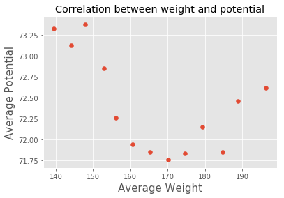

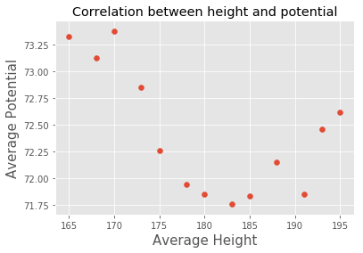

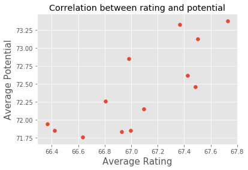

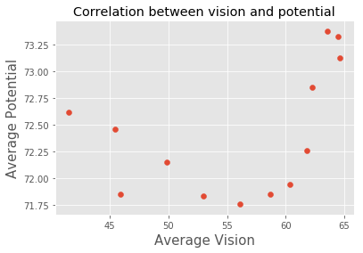

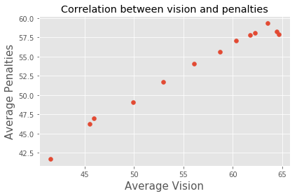

```python
fig, ax1 = plt.subplots()
ax1.scatter(players_height['avg_weight'], players_height['avg_potential'])

ax1.set_xlabel("Average Weight", fontsize=15)
ax1.set_ylabel("Average Potential", fontsize=15)
ax1.set_title('Correlation between weight and potential')

ax1.grid(True)


fig, ax2 = plt.subplots()
ax2.scatter(players_height['calc_height'], players_height['avg_potential'])

ax2.set_xlabel("Average Height", fontsize=15)
ax2.set_ylabel("Average Potential", fontsize=15)
ax2.set_title('Correlation between height and potential')

ax2.grid(True)


fig, ax3 = plt.subplots()
ax3.scatter(players_height['avg_overall_rating'], players_height['avg_potential'])

ax3.set_xlabel("Average Rating", fontsize=15)
ax3.set_ylabel("Average Potential", fontsize=15)
ax3.set_title('Correlation between rating and potential')

ax3.grid(True)

fig, ax4 = plt.subplots()
ax4.scatter(players_height['avg_vision'], players_height['avg_potential'])

ax4.set_xlabel("Average Vision", fontsize=15)
ax4.set_ylabel("Average Potential", fontsize=15)
ax4.set_title('Correlation between vision and potential')

ax4.grid(True)

fig, ax5 = plt.subplots()
ax5.scatter(players_height['avg_vision'], players_height['avg_penalties'])

ax5.set_xlabel("Average Vision", fontsize=15)
ax5.set_ylabel("Average Penalties", fontsize=15)
ax5.set_title('Correlation between vision and penalties')

ax5.grid(True)


fig.tight_layout()

plt.show()
```

# Limitations

1. Asking the right data analysis questions for the soccer data.  
- There are so many tables and some tables have so many fileds. Even after figuring out how to join and relate different tables, it was overwhelming and difficult to figure out what kind of questions can be asked using this data set.  
- The way I approached this problem was to learn as much about the data as possible on Kaggle.  
- Even after that, I narrowed that the fields to the ones that I needed to answer my questions.  
- So this analysis does not cover all tables and does not use all the fields. The conclusions are limited to the information that was used.  
2. Handling the missing values was relatively difficult in this dataset.  
- Making a decision on how to handle missing values depends a lot on your knowledge of the data fields and the type of analysis you are going to conduct (do we just remove the row, do we replace with zero or other value or is that going to skew the data, should we try to predict the missing values, etc.)  
- I finally decided to clean up and narrow down the information I needed and at the same time remove the rows with missing values by using the appropriate types of joins and SQL queries.  
- So the conclusions are not taking the rows with missing values into account.  
3. I faced difficulty to make reproducible functions/codes especially for plotting and SQL queries.  
- Since I am a beginner at programming and I tried a lot of new concepts in this project, which I loved the challenge, I wasn't able to figure out how to avoid repetition in certain cases.

# Conclusions

Although there were a lot of missing values in certain columns of some tables in this database, they were not removed or replaced with any values.  
This was mainly because using different table joins already got rid of rows with missing values.

**- How many teams played in each league during each season?**  
One interesting insight is that the number of teams in all leagues are constant during different seasons except for "Belgium Jupiler League" which seems to have fluctuating teams during different seasons.  
In 2013/2014 season there were only four teams, KAA Gent, KV Oostende, Lierse SK, Waasland-Beveren in Belgium Jupiler League.  
Poland Ekstraklasa and Portugal Liga ZON Sagres also have some fluctuations.  
**- What was the count and average goals scored in each league during each season?**  
In the last five seasons, Spain LIGA teams seem to have a home advantage. This could be a key factor when they host teams from other leagues for European Leagues.  
In such championship matches, there are usually two fixtures played (home and away) by each team. And since goals scored in each of these fixtures plays a role in teams qualifying to the next round, there seems to a big advantage to the Spain LIGA teams in recent seasons.  
The ratios for other leagues seem to vary significantly and not show any significant trends.  
All the (home-goals/away-goals) ratios are above 1.1 and we can consistently see the ratio being above 1.2 for most leagues.  
This only shows that, on an average, teams score more at home fixtures than away.  
In the last five seasons, Spain LIGA teams has a strong home advantage.  
Germany Bundesliga keeps oscillating between a strong home game and weak home game season.

- How was the performance (home win, home tiem home loss, away win, away loss, away tie) of teams in each league during each season?  
- How to quantify the performance in terms of match results?  
I defined a function to assign performance score.  
As seen from previous results, Spain LIGA BBVA seems to be pretty strong appearing in top ten in every season. Its two star teams are Real Madrid CF and FC Barcelona.  
Another interesting observation is that some seasons are less competetive. For example, 2010-2011 only five teams had the top ten teams.  
Spain LIGA BBVA is the leader by having 16 teams in top ten from 2008 to 2016 followed closely by Scotland Premier League .

**- Which players had the most penalties?**  
Danilo has had the most penalties.  
**- What player attributes lead to the most potential?**  
**- Correlation between some player attributes and player potential.**

There were not many strong correlations with potential except the obvious positive correlation between rating and potential.  
There is an interesting very strong positive correlation between vision and penalties.